# Introduction to DECODE

```r
library(DECODE)
set.seed(1)
```

DECODE (**De**ciphering **C**ancer **O**rigin from **D**NA **E**volution) decomposes mutations from a bulk DNA-sequencing sample into a neutral tail and mutation clusters, based on their Variant Allele Frequencies (VAFs). The algorithm corrects for sample-specific sequencing coverage and mutation-calling biases when computing the expected Site Frequency Spectrum (SFS).

This vignette walks through a complete hands-on workflow:

- Section 1: Prepare a mutation table with annotated copy numbers
- Section 2: Decompose diploid mutations with DECODE
- Section 3: Generate diagnostic plots
- Section 4: Extract biological covariates
- Section 5: Assign mutations to DECODE compartments

# 1. Prepare a mutation table with annotated copy numbers

DECODE requires a mutation table with columns `Ref_count` and `Alt_count`, containing the reference and alternative read counts for each mutation, respectively.

```r
mutation_table <- read.csv(system.file("extdata", "mutation_table.csv", package = "DECODE"))
head(mutation_table)
```

```
#>   Mutation_ID Chromosome Position Ref_count Alt_count
#> 1  mutation_1       chr1   117291        72        33
#> 2  mutation_2       chr1   481356       122        45
#> 3  mutation_3       chr1   949803       163        12
#> 4  mutation_4       chr1  1102170       122        34
#> 5  mutation_5       chr1  1530100       162        11
#> 6  mutation_6       chr1  1564250        99        57
```

Since DECODE operates on the mutational SFS, decomposition should be limited to mutations sharing the same copy-number state, in which case mutation clusters correspond directly to distinct subclones. In practice, DECODE works best for samples that are mainly diploid. To extract only diploid mutations, we first load the table containing allele-specific copy number segments, e.g., from [ASCAT](https://github.com/VanLoo-lab/ascat).

```r
cn_table <- read.delim(system.file("extdata", "copy_number_segments.txt", package = "DECODE"))
head(cn_table)
```

```
#>   chr  startpos    endpos nMajor nMinor
#> 1   1     61735  10427928      2      1
#> 2   1  10428257  10521313      2      1
#> 3   1  10521990  26613862      1      1
#> 4   1  26614190  27193445      2      0
#> 5   1  27193722 151886189      2      1
#> 6   1 151886412 152106520      1      1
```

We can then assign allele-specific copy numbers to each mutation.

```r
cn_table$chr <- paste0("chr", cn_table$chr)
mutation_table$nMajor <- NA_integer_
mutation_table$nMinor <- NA_integer_
for (segment in 1:nrow(cn_table)) {
    mutation_rows <- which(
        mutation_table$Chromosome == cn_table$chr[segment] &
            mutation_table$Position >= cn_table$startpos[segment] &
            mutation_table$Position <= cn_table$endpos[segment]
    )
    mutation_table$nMajor[mutation_rows] <- cn_table$nMajor[segment]
    mutation_table$nMinor[mutation_rows] <- cn_table$nMinor[segment]
}
cat("Total mutations:                     ", nrow(mutation_table), "\nMutations with assigned copy numbers:", sum(!is.na(mutation_table$nMajor)), "\n")
```

```
#> Total mutations:                      14187
#> Mutations with assigned copy numbers: 13981
```

```r
head(mutation_table)
```

```
#>   Mutation_ID Chromosome Position Ref_count Alt_count nMajor nMinor
#> 1  mutation_1       chr1   117291        72        33      2      1
#> 2  mutation_2       chr1   481356       122        45      2      1
#> 3  mutation_3       chr1   949803       163        12      2      1
#> 4  mutation_4       chr1  1102170       122        34      2      1
#> 5  mutation_5       chr1  1530100       162        11      2      1
#> 6  mutation_6       chr1  1564250        99        57      2      1
```

# 2. Decompose diploid mutations with DECODE

We extract diploid mutations, i.e., those with (`nMajor`, `nMinor`) = (1, 1), for DECODE analysis. Furthermore, mutations without reported reference or alternate read counts must be excluded. Optionally, mutations with no reference or alternate read counts can also be omitted.

```r
mutation_table <- mutation_table[which(
    mutation_table$nMajor == 1 &
        mutation_table$nMinor == 1 &
        !is.na(mutation_table$Ref_count) &
        !is.na(mutation_table$Alt_count) &
        mutation_table$Ref_count > 0 &
        mutation_table$Alt_count > 0
), ]
cat("Mutations on diploid regions:        ", nrow(mutation_table), "\n")
```

```
#> Mutations on diploid regions:         9381
```

```r
head(mutation_table)
```

```
#>      Mutation_ID Chromosome Position Ref_count Alt_count nMajor nMinor
#> 103 mutation_103       chr1 10577266       144         3      1      1
#> 104 mutation_104       chr1 10627844        60        65      1      1
#> 105 mutation_105       chr1 10710444        74        57      1      1
#> 106 mutation_106       chr1 10793340       121        12      1      1
#> 107 mutation_107       chr1 10962862       119         3      1      1
#> 108 mutation_108       chr1 11097363        69        42      1      1
```

If allele-specific copy numbers are not available, we can filter for mutations with total copy number = 2. In this case, attention should be paid to potentially spurious clusters. For instance, mutations with (`nMajor`, `nMinor`) = (2, 0) may produce secondary clusters with higher VAF compared to their counterparts with (`nMajor`, `nMinor`) = (1, 1). These artificial clusters may inflate the clone count and sample purity.

DECODE requires a sufficient number of mutations to decompose the SFS reliably. If there are fewer than 100 mutations remaining in the table, consider using a different copy number state instead. Note that the ploidy assumption should be accounted for when translating cluster VAFs into subclonal CCFs.

We can then decompose the retained mutations with `DECODE()`. At minimum, DECODE requires `mutation_table`, a dataframe with columns `Ref_count` and `Alt_count`. DECODE also accepts several optional arguments:

- `sample_id`: label for the sample.
- `neutral_tail`: whether the decomposition should include a neutral tail (if `TRUE`) or not (if `FALSE`). By default, `neutral_tail = NA`, in which case DECODE compares the fits with and without a neutral tail to select the parsimonious model.
- `N_clusters`: requested cluster count. By default, `N_clusters = NA`, in which case DECODE automatically determines the optimal number of clusters that minimizes the Generalized Information Criterion (GIC).
- `N_clusters_min`, `N_clusters_max`: range of cluster counts (`N_clusters_min = 1` and `N_clusters_max = 5` by default).
- `ABCSMCDRF_nParticles`: a vector of particle counts for parameter inference with [ABC-SMC-DRF](https://github.com/dinhngockhanh/abcsmcrf) (`rep(1000, 10)` by default). The length of `ABCSMCDRF_nParticles` indicates the total number of iterations, and each integer indicates the particle count for the corresponding iteration. For challenging samples, increasing the iteration count or particle counts may improve DECODE’s accuracy.

```r
DECODE_result <- DECODE(
    sample_id = "Example",
    mutation_table = mutation_table
)
```

```
#>
#>
#>
#> PERFORMING DECODE FOR SAMPLE Example...
#> Choose mutation thresholds for inference and validation...
#>   |                                                          |                                                  |   0%  |                                                          |                                                  |   1%  |                                                          …
#> Complete data          : 1 ≤ variant reads, 12 ≤ total reads ≤ 1021; 9381 mutations
#> Inference A            : 4 ≤ variant reads, 49 ≤ total reads ≤ 1021; 7875 mutations (83.95%)
#> Inference B            : 6 ≤ variant reads, 49 ≤ total reads ≤ 1021; 7299 mutations (77.81%)
#> Validation             : 5 ≤ variant reads, 49 ≤ total reads ≤ 1021; 7552 mutations (80.50%)
#> Prepare the SFS convolution matrix for inference A...
#>   |                                                          |                                                  |   0%  |                                                          |                                                  |   1%  |                                                          …
#> Prepare the SFS convolution matrix for inference B...
#>   |                                                          |                                                  |   0%  |                                                          |                                                  |   1%  |                                                          …
#> Prepare the SFS convolution matrix for validation...
#>   |                                                          |                                                  |   0%  |                                                          |                                                  |   1%  |                                                          …
#> Inference for 1 cluster with neutral tail component...
#>   |                                                          |                                                  |   0%  |                                                          |+++++                                             |  10%  |                                                          …
#> Validation score       : GIC = 0.15 ± 0 (L1 error = 0.11 ± 0, penalty = 0.03 ± 0)
#> Neutral component      : α   = 1.07 ± 0.00; mutation count: 8528 ± 0 [True], 2935 ± 0 [A], 2394 ± 0 [B]
#> Cluster 1              : f   = 0.43 ± 0.00; mutation count: 4283 ± 0 [True], 4265 ± 0 [A], 4265 ± 0 [B]
#> Inference for 2 clusters with neutral tail component...
#>   |                                                          |                                                  |   0%  |                                                          |+++++                                             |  10%  |                                                          …
#>   |                                                          |                                                  |   0%  |                                                          |+++++                                             |  10%  |                                                          …
#> Validation score       : GIC = 0.07 ± 0 (L1 error = 0.01 ± 0, penalty = 0.06 ± 0)
#> Neutral component      : α   = 1.20 ± 0.00; mutation count: 10769 ± 14 [True], 2718 ± 1 [A], 2139 ± 1 [B]
#> Cluster 1              : f   = 0.44 ± 0.00; mutation count: 4269 ± 1 [True], 4251 ± 1 [A], 4251 ± 1 [B]
#> Cluster 2              : f   = 0.30 ± 0.00; mutation count: 883 ± 0 [True], 879 ± 0 [A], 879 ± 0 [B]
#> H = 2 vs H = 1         : Wilcoxon p-value = 0 → continue with higher cluster counts
#> Inference for 3 clusters with neutral tail component...
#>   |                                                          |                                                  |   0%  |                                                          |+++++                                             |  10%  |                                                          …
#>   |                                                          |                                                  |   0%  |                                                          |+++++                                             |  10%  |                                                          …
#> Validation score       : GIC = 0.10 ± 0 (L1 error = 0.01 ± 0, penalty = 0.09 ± 0)
#> Neutral component      : α   = 1.17 ± 0.00; mutation count: 9866 ± 1 [True], 2681 ± 0 [A], 2128 ± 0 [B]
#> Cluster 1              : f   = 0.44 ± 0.00; mutation count: 4262 ± 0 [True], 4244 ± 0 [A], 4244 ± 0 [B]
#> Cluster 2              : f   = 0.30 ± 0.00; mutation count: 879 ± 0 [True], 875 ± 0 [A], 875 ± 0 [B]
#> Cluster 3              : f   = 0.06 ± 0.00; mutation count: 50 ± 0 [True], 43 ± 0 [A], 32 ± 0 [B]
#> H = 3 vs H = 2         : Wilcoxon p-value = 1 → 2 clusters is the best fit with tail
#> Inference for 1 cluster without neutral tail component...
#>   |                                                          |                                                  |   0%  |                                                          |+++++                                             |  10%  |                                                          …
```

[output cut: 27 more lines]

```
#>   |                                                          |                                                  |   0%  |                                                          |+++++                                             |  10%  |                                                          …
#>   |                                                          |                                                  |   0%  |                                                          |+++++                                             |  10%  |                                                          …
#> Validation score       : GIC = 0.17 ± 0 (L1 error = 0.03 ± 0, penalty = 0.13 ± 0)
#> Cluster 1              : f   = 0.43 ± 0.00; mutation count: 4393 ± 1 [True], 4375 ± 1 [A], 4375 ± 1 [B]
#> Cluster 2              : f   = 0.30 ± 0.00; mutation count: 1253 ± 1 [True], 1248 ± 1 [A], 1248 ± 1 [B]
#> Cluster 3              : f   = 0.17 ± 0.00; mutation count: 562 ± 0 [True], 559 ± 0 [A], 557 ± 0 [B]
#> Cluster 4              : f   = 0.08 ± 0.00; mutation count: 915 ± 0 [True], 873 ± 0 [A], 776 ± 0 [B]
#> Cluster 5              : f   = 0.03 ± 0.00; mutation count: 1584 ± 0 [True], 713 ± 0 [A], 255 ± 0 [B]
#> H = 5 vs H = 4         : Wilcoxon p-value = 0 → maximum cluster count has been reached, increased N_clusters_max may improve fit
#> With vs without tail   : Wilcoxon p-value = 1 → fit with tail is selected
#> Best fit = neutral tail + 2 clusters:
#> Validation score       : GIC = 0.07 ± 0 (L1 error = 0.01 ± 0, penalty = 0.06 ± 0)
#> Neutral component      : α   = 1.20 ± 0.00; mutation count: 10769 ± 14 [True], 2718 ± 1 [A], 2139 ± 1 [B]
#> Cluster 1              : f   = 0.44 ± 0.00; mutation count: 4269 ± 1 [True], 4251 ± 1 [A], 4251 ± 1 [B]
#> Cluster 2              : f   = 0.30 ± 0.00; mutation count: 883 ± 0 [True], 879 ± 0 [A], 879 ± 0 [B]
```

# 3. Generate diagnostic plots

DECODE provides two main plotting functions: `DECODE_plot_SFS()` and `DECODE_plot_model_selection()`. Both accept optional `filename`, `width`, `height`, `units`, and `res` arguments. The defaults are `width = 30`, `height = 15`, `units = "in"`, and `res = 150` (i.e. 4500×2250 pixels). The user can also specify `filetype`, which accepts `"png"` (default), `"jpg"`, `"svg"`, `"tiff"`, `"eps"` or `"pdf"`.

`DECODE_plot_SFS()` compares the empirical SFS against DECODE’s deconvolution for particular subsample and fit. By default, it plots the best DECODE fit for the inference A subsample. The user can change to a different subsample with argument `mode` (which accepts `"inference_A"`, `"inference_B"` or `"validation"`) and a different fit by changing arguments `with_tail` (`"TRUE"` or `"FALSE"`) and `N_clusters` (any integer cluster count that DECODE considered).

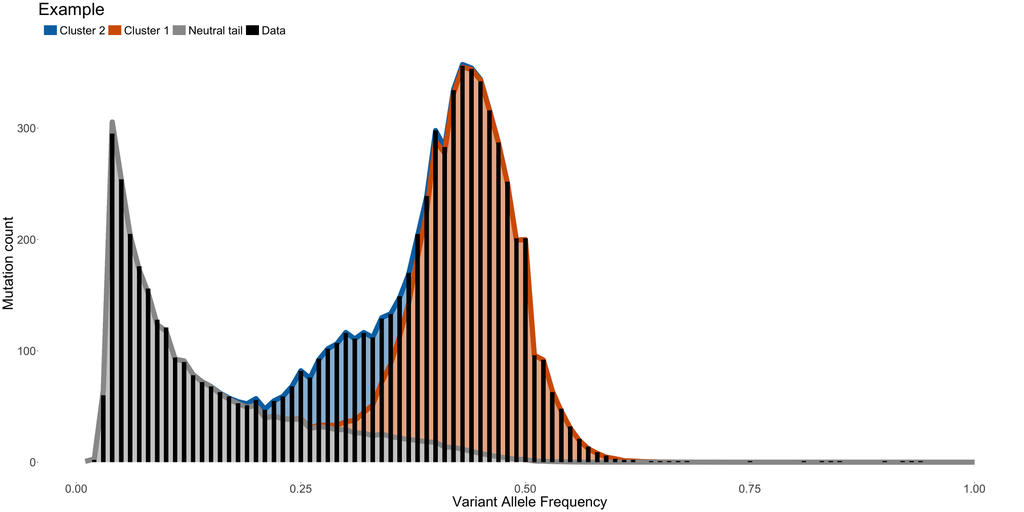

```r
DECODE_plot_SFS(
    DECODE_result = DECODE_result,
    filename = "DECODE_SFS",
    filetype = "png"
)
```

`DECODE_plot_model_selection()` provides all information regarding the model selection process.

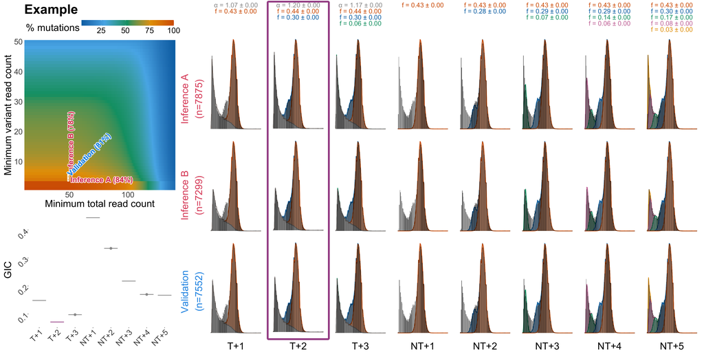

```r
DECODE_plot_model_selection(
    DECODE_result = DECODE_result,
    filename = "DECODE_model_selection",
    filetype = "png"
)
```

Top left: heatmap detailing the proportion of mutations retained for given variant and total read count thresholds. Filtering thresholds for inference A, inference B and validation subsamples are highlighted. Right: Optimal decompositions given cluster count $H$ with a tail (column T+$H$) or without a tail (column NT+$H$). For each $H$, the expected SFS for each subsample given the inferred parameters (shaded areas, colors denoting tail and clusters) is compared against the empirical SFS (black histogram). Means and standard deviations of tail power ($\alpha$) and cluster VAFs ($f$) are reported on top. Bottom left: comparison of Generalized Information Criteria (GIC) between different tail and cluster count assumptions. The fit with the lowest GIC is selected as the final result, and denoted with purple GIC bar and purple box around the corresponding SFS fits.

The model selection plot enables us to visually assess the fit of different models. If we determine, for instance, that the NT+$4$ fit is better, we can either force the existing DECODE result to select this fit by setting `DECODE_result$best_with_tail <- FALSE` and `DECODE_result$best_N_clusters <- 4`, or perform DECODE deconvolution again with arguments `neutral_tail = FALSE` and `N_clusters = 4`.

# 4. Extract biological covariates

Relevant biological parameters can be extracted or estimated from the output argument `DECODE_result`.

We first find details regarding DECODE’s best fit, i.e., whether the tail can be detected, the number of clusters, and the corresponding parameter posterior distribution. Typically, the marginal means of the posterior distribution are sufficient for downstream analyses.

```r
with_tail <- DECODE_result$best_with_tail
N_clusters <- DECODE_result$best_N_clusters
fit_key <- ifelse(with_tail, "fits_with_tail", "fits_without_tail")
parameters <- DECODE_result[[fit_key]]$all_fits[[paste0(N_clusters, "_clusters")]]$parameters
cat("DECODE's tail status:                ", with_tail, "\nDECODE's cluster count:              ", N_clusters, "\n")
```

```
#> DECODE's tail status:                 TRUE
#> DECODE's cluster count:               2
```

```r
head(parameters)
```

```
#>   Tail_power Tail_Nmut_exact Tail_Nmut_A Tail_Nmut_B Tail_Nmut_validation
#> 1   1.203104        10781.93    2717.360    2137.899             2388.004
#> 2   1.203104        10781.93    2717.360    2137.899             2388.004
#> 3   1.203104        10781.93    2717.360    2137.899             2388.004
#> 4   1.202325        10770.61    2719.751    2140.256             2390.405
#> 5   1.203104        10781.93    2717.360    2137.899             2388.004
#> 6   1.203104        10781.93    2717.360    2137.899             2388.004
#>   Cluster_1_freq Cluster_1_Nmut_exact Cluster_1_Nmut_A Cluster_1_Nmut_B
#> 1      0.4351272             4269.903         4251.697         4251.697
#> 2      0.4351272             4269.903         4251.697         4251.697
#> 3      0.4351272             4269.903         4251.697         4251.697
#> 4      0.4351357             4268.631         4250.430         4250.430
#> 5      0.4351272             4269.903         4251.697         4251.697
#> 6      0.4351272             4269.903         4251.697         4251.697
#>   Cluster_1_Nmut_validation Cluster_2_freq Cluster_2_Nmut_exact
#> 1                  4251.697      0.2994334             883.4325
#> 2                  4251.697      0.2994334             883.4325
#> 3                  4251.697      0.2994334             883.4325
#> 4                  4250.430      0.2995196             882.6109
#> 5                  4251.697      0.2994334             883.4325
#> 6                  4251.697      0.2994334             883.4325
#>   Cluster_2_Nmut_A Cluster_2_Nmut_B Cluster_2_Nmut_validation
#> 1         879.6651         879.6539                  879.6628
#> 2         879.6651         879.6539                  879.6628
#> 3         879.6651         879.6539                  879.6628
#> 4         878.8470         878.8358                  878.8447
#> 5         879.6651         879.6539                  879.6628
#> 6         879.6651         879.6539                  879.6628
```

```r
mean_parameters <- colMeans(parameters)
mean_parameters
```

```
#>                Tail_power           Tail_Nmut_exact               Tail_Nmut_A
#>              1.202477e+00              1.076935e+04              2.718410e+03
#>               Tail_Nmut_B      Tail_Nmut_validation            Cluster_1_freq
#>              2.139109e+03              2.389169e+03              4.351274e-01
#>      Cluster_1_Nmut_exact          Cluster_1_Nmut_A          Cluster_1_Nmut_B
#>              4.269294e+03              4.251090e+03              4.251090e+03
#> Cluster_1_Nmut_validation            Cluster_2_freq      Cluster_2_Nmut_exact
#>              4.251090e+03              2.994771e-01              8.830122e+02
#>          Cluster_2_Nmut_A          Cluster_2_Nmut_B Cluster_2_Nmut_validation
#>              8.792466e+02              8.792354e+02              8.792443e+02
```

## 4a. Sample purity and subclonal Cancer Cell Fractions (CCFs)

DECODE estimates the clusters’ mean VAFs (reported in columns `Cluster_i_freq` in `parameters`). The [formula for translating the VAF for a clone into its subclonal CCF](https://doi.org/10.1038/s41592-020-01013-2) requires knowing sample purity $\rho$, total copy number $N$ and multiplicity $m$:

$$\mathrm{CCF} \approx
\frac{\mathrm{VAF}}{m\cdot\rho}\left(\rho\cdot
N+2(1-\rho)\right)$$

If DECODE decomposed diploid mutations ((`nMajor`, `nMinor`) = (1, 1)), the multiplicity is necessarily 1, and the formula simplifies considerably:

$$\mathrm{CCF} \approx
\frac{2\cdot\mathrm{VAF}}{\rho}$$

The subclonal CCFs, unnormalized for purity, are hence twice the cluster VAFs, averaged among DECODE’s estimates.

```r
cluster_VAFs <- as.numeric(mean_parameters[paste0("Cluster_", 1:N_clusters, "_freq")])
cluster_CCFs <- as.numeric(2 * cluster_VAFs)
data.frame(
    Compartment = paste0("Cluster ", seq_len(N_clusters)),
    VAF = cluster_VAFs,
    CCF = cluster_CCFs
)
```

```
#>   Compartment       VAF       CCF
#> 1   Cluster 1 0.4351274 0.8702548
#> 2   Cluster 2 0.2994771 0.5989541
```

DECODE automatically orders the clusters in decreasing VAFs. Therefore, the sample purity equals the unnormalized CCF of cluster 1. Optionally, the subclonal CCFs can then be normalized by dividing by `purity`.

```r
purity <- cluster_CCFs[1]
purity
```

```
#> [1] 0.8702548
```

The formulae above can be adjusted if a copy number state different from diploidy was used to extract the mutation table for DECODE.

## 4b. Subclonal mutation burden

DECODE does not decompose all mutations in the input table. Instead, it creates three subsamples with varying readcount thresholds:

| Subsample | Note |
| --- | --- |
| `inference_A` | Lowest alternative readcount threshold; if the tail is detected, this subsample retains the most mutations in the tail |
| `inference_B` | Highest alternative readcount threshold; if the tail is detected, this subsample retains the fewest mutations in the tail |
| `validation` | Intermediate alternative readcount threshold; mainly used to validate the parameters inferred from `inference_A` and `inference_B` |

The mutation burden in each compartment, either a mutation cluster or the tail if detected by DECODE, in each subsample can be estimated by averaging among DECODE’s estimates.

```r
mutation_burdens <- data.frame(
    Compartment = c(ifelse(with_tail, "Tail", c()), paste0("Cluster ", seq_len(N_clusters))),
    CCF = c(ifelse(with_tail, c(NA), c()), cluster_CCFs),
    nMut_inference_A = as.numeric(c(
        ifelse(with_tail, round(mean_parameters["Tail_Nmut_A"]), c()),
        round(mean_parameters[paste0("Cluster_", 1:N_clusters, "_Nmut_A")])
    )),
    nMut_inference_B = as.numeric(c(
        ifelse(with_tail, round(mean_parameters["Tail_Nmut_B"]), c()),
        round(mean_parameters[paste0("Cluster_", 1:N_clusters, "_Nmut_B")])
    )),
    nMut_validation = as.numeric(c(
        ifelse(with_tail, round(mean_parameters["Tail_Nmut_validation"]), c()),
        round(mean_parameters[paste0("Cluster_", 1:N_clusters, "_Nmut_validation")])
    ))
)
mutation_burdens
```

```
#>   Compartment       CCF nMut_inference_A nMut_inference_B nMut_validation
#> 1        Tail        NA             2718             2139            2389
#> 2   Cluster 1 0.8702548             4251             4251            4251
#> 3   Cluster 2 0.5989541              879              879             879
```

# 5. Assign mutations to DECODE compartment

Although DECODE decomposes only subsamples of diploid mutations, the remaining mutations can also be mapped to compartments inferred from DECODE (i.e., mutation clusters and the tail if detected), including those with different copy number states. However, their VAFs must first be converted to be compatible with the copy number state of DECODE’s input mutation table. This requires first inferring mutation multiplicities, which can be performed with [GRITIC](https://github.com/VanLoo-lab/gritic) for instance.

```r
# python rungritic_cmd.py \
#   --mutation_table path/to/mutation_table.tsv \
#   --copy_number_table path/to/cn_table.tsv \
#   --purity 0.87 \
#   --sample_id Example \
#   --output path/to/gritic_output
```

Once results from GRITIC or other CNA timing algorithms have been ascertained, the multiplicities can be assigned for each mutation. Here we use a pre-annotated mutation table as an example.

```r
mutation_table_with_multiplicity <- read.csv(system.file("extdata", "mutation_table_with_multiplicity.csv", package = "DECODE"))
mutation_table_with_multiplicity <- mutation_table_with_multiplicity[which(
    !is.na(mutation_table_with_multiplicity$nMajor) &
        !is.na(mutation_table_with_multiplicity$nMinor) &
        !is.na(mutation_table_with_multiplicity$Multiplicity)
), ]
head(mutation_table_with_multiplicity)
```

```
#>   Mutation_ID Chromosome Position Ref_count Alt_count nMajor nMinor
#> 1  mutation_1       chr1   117291        72        33      2      1
#> 2  mutation_2       chr1   481356       122        45      2      1
#> 3  mutation_3       chr1   949803       163        12      2      1
#> 4  mutation_4       chr1  1102170       122        34      2      1
#> 5  mutation_5       chr1  1530100       162        11      2      1
#> 6  mutation_6       chr1  1564250        99        57      2      1
#>   Multiplicity
#> 1            1
#> 2            1
#> 3            2
#> 4            1
#> 5            1
#> 6            2
```

The [relationship between a mutation’s VAF and its CCF](https://doi.org/10.1038/s41592-020-01013-2) can be rearranged to calculate each mutation’s normalized VAF, i.e., the VAF if the mutation were diploid:
$$f_\text{normalized} = f \cdot
\left.\dfrac{\rho}{2}\middle/\dfrac{m \cdot \rho}{c \cdot \rho +
2(1-\rho)}\right.$$
where $f$ is the mutation’s observed VAF, $m$ and $c$ are its multiplicity and total copy number, respectively, and $\rho$ is the sample purity. If a different copy number state was implemented for DECODE, the fraction in the numerator can be adjusted accordingly.

```r
mutation_table_with_multiplicity$VAF <- with(
    mutation_table_with_multiplicity,
    Alt_count / (Ref_count + Alt_count)
)
mutation_table_with_multiplicity$Total_CN <- with(
    mutation_table_with_multiplicity,
    nMajor + nMinor
)
mutation_table_with_multiplicity$normalized_VAF <- with(
    mutation_table_with_multiplicity,
    VAF * 0.5 * purity / ((Multiplicity * purity) / (Total_CN * purity + 2 * (1 - purity)))
)
head(mutation_table_with_multiplicity)
```

```
#>   Mutation_ID Chromosome Position Ref_count Alt_count nMajor nMinor
#> 1  mutation_1       chr1   117291        72        33      2      1
#> 2  mutation_2       chr1   481356       122        45      2      1
#> 3  mutation_3       chr1   949803       163        12      2      1
#> 4  mutation_4       chr1  1102170       122        34      2      1
#> 5  mutation_5       chr1  1530100       162        11      2      1
#> 6  mutation_6       chr1  1564250        99        57      2      1
#>   Multiplicity        VAF Total_CN normalized_VAF
#> 1            1 0.31428571        3     0.45104004
#> 2            1 0.26946108        3     0.38671098
#> 3            2 0.06857143        3     0.04920437
#> 4            1 0.21794872        3     0.31278418
#> 5            1 0.06358382        3     0.09125088
#> 6            2 0.36538462        3     0.26218674
```

Function `DECODE_mutation_assignment()` calculates the probability that each mutation belongs to a specific DECODE compartment, given the mutation’s `normalized_VAF`. This is sometimes referred to as the probabilistic or soft subclonal mutation assignment. By default, `DECODE_mutation_assignment()` employs the final DECODE decomposition of the inference A subsample to calculate the probabilities, since this subsample is closest in shape to the unfiltered SFS. The user can change to a different subsample with argument `mode` (which accepts `"inference_A"`, `"inference_B"` or `"validation"`) and a different fit by changing arguments `with_tail` (`"TRUE"` or `"FALSE"`) and `N_clusters` (any integer cluster count that DECODE considered).

```r
mutation_assignment <- DECODE_mutation_assignment(
    DECODE_result = DECODE_result,
    mutation_table = mutation_table_with_multiplicity
)
```

```
#>
#> Assign mutations to DECODE components with configuration with tail + 2 clusters...
```

```r
head(mutation_assignment)
```

```
#>   Mutation_ID Chromosome Position Ref_count Alt_count nMajor nMinor
#> 1  mutation_1       chr1   117291        72        33      2      1
#> 2  mutation_2       chr1   481356       122        45      2      1
#> 3  mutation_3       chr1   949803       163        12      2      1
#> 4  mutation_4       chr1  1102170       122        34      2      1
#> 5  mutation_5       chr1  1530100       162        11      2      1
#> 6  mutation_6       chr1  1564250        99        57      2      1
#>   Multiplicity        VAF Total_CN normalized_VAF  prob_tail prob_cluster_1
#> 1            1 0.31428571        3     0.45104004 0.01976247   9.787583e-01
#> 2            1 0.26946108        3     0.38671098 0.07640822   8.670244e-01
#> 3            2 0.06857143        3     0.04920437 1.00000000   8.267923e-15
#> 4            1 0.21794872        3     0.31278418 0.22449718   1.582766e-01
#> 5            1 0.06358382        3     0.09125088 0.99992337   9.336896e-08
#> 6            2 0.36538462        3     0.26218674 0.34657018   1.449432e-02
#>   prob_cluster_2
#> 1   1.479191e-03
#> 2   5.656736e-02
#> 3   3.462527e-09
#> 4   6.172262e-01
#> 5   7.653268e-05
#> 6   6.389355e-01
```

The columns `prob_tail`, `prob_cluster_1`, `prob_cluster_2`, … contain the probabilities that each mutation belongs to the tail or each cluster, respectively. The mutations in SFS bins that DECODE did not decompose, e.g., due to the lack of data in the input diploid mutation table, may be assigned `NA` probabilities.

If the deterministic (or hard) assignment is preferred, each mutation can be assigned to the compartment with the highest probability, or the compartment with probability higher than a specified threshold (e.g., 0.6 or 0.7).